# eo_sim_m

Vincent Ibia | 117024

The French Vanilla Option

A Structured Product Using Exotic Options

```python
import matplotlib.pyplot as plt
import numpy as np
from scipy.stats import describe
# from math import exp, sqrt
%matplotlib inline
```

I. Simulation

To go easy on memory, we won't use nested loops in our computation.  
We'll generate all steps on one path, store it, and then generate another path.

```python
s0,K,r,q,vol,T,N,M = 100,100,0.05,0,0.3,1,20,10
dt = T/N
```

```python
def g_price_path(s0=s0,K=K,r=r,q=q,vol=vol,T=T,N=N,M=M,dt=dt):
    """Generates N values of stock price from time 0 to T.
    Stock price follow geometric brownian motion."""
    s = np.array([s0])
    temp1 = ((r - q) - (0.5 * vol*vol))*dt
    temp2 = vol * np.sqrt(dt)
    for step in range(N):
        next_val = s[step] * np.exp(temp1 + (temp2 * np.random.randn()))
        s = np.concatenate([s,[next_val]])
    return s
```

The function above, $g\_price\_path$, will make an entire path from time zero to time $T$ with $N$ steps. This information will be stored in a `Numpy` 1d-array. We can now call this function $M$ times, for the number of paths we'd like to create. Each path will be *"appended"* into a 2d-array (matrix).

```python
# Example path for a stock starting at 100, with 20 time steps in 1 year
g_price_path()
```

```
array([ 100.        ,  100.86131871,   98.93761405,  102.07949867,
        119.03543063,  124.6127276 ,  109.32868682,  100.98321218,
        108.67845632,  101.05117124,   96.30612944,   96.27283131,
         84.35654958,   86.1383829 ,   83.60085941,   85.99764545,
         89.11856221,   87.90322898,   84.95284682,   84.09121149,
         82.24092736])
```

We can easily override any default variables. For example, we can call the function with $N=100$ to have smaller $dt$ intervals.

We'll now use a second loop to generate our $M$ total paths.

```python
def multi_path(s0=s0,K=K,r=r,q=q,vol=vol,T=T,N=N,M=M,dt=dt):
    build_multi = g_price_path(s0=s0,K=K,r=r,q=q,vol=vol,T=T,N=N,M=M,dt=dt)
    for sims in range(M-1):
            new_path = g_price_path(s0=s0,K=K,r=r,q=q,vol=vol,T=T,N=N,M=M,dt=dt)
            build_multi = np.vstack((build_multi, new_path))
    return build_multi
```

```python
# Example of multipath, with overriding of varibales
multi_path(N=3,M=4)
```

```
array([[ 100.        ,   97.53478422,   95.85943091,   95.11775794],
       [ 100.        ,   91.83188284,   95.75991381,   97.39837343],
       [ 100.        ,   95.53133556,   84.34652302,   66.07928525],
       [ 100.        ,   98.96362897,   94.62279469,   89.90931556]])
```

```python
N,M=1000,10000
dt=T/N
all_path = g_price_path(s0=s0,K=K,r=r,q=q,vol=vol,T=T,N=N,M=M,dt=dt)
```

this was run once to generate the paths. they were then save into a text file.

```python
#for sims in range(M):
#    new_path = g_price_path(s0=s0,K=K,r=r,q=q,vol=vol,T=T,N=N,M=M,dt=dt)
#    all_path = np.vstack((all_path, new_path))
```

*uncomment the last line in the cell below, to load pre-calculated path data (250MB)*

```python
# save our output to a file.
# we won't have to generate paths each time we load this file.

# np.savetxt("10ksim_1kstep.txt",all_path)

#all_path = np.loadtxt("10ksim_1kstep.txt")
```

*a few checks on the generated data, to make sure we have what we want*

```python
all_path[:2]
```

```
array([[ 100.        ,   98.55258098,   98.81579748, ...,  112.26668993,
         112.8654816 ,  112.52235423],
       [ 100.        ,   99.84277479,   99.65840308, ...,  116.03572558,
         116.76754148,  116.0831636 ]])
```

```python
all_path[0][:30]
```

```
array([ 100.        ,   98.55258098,   98.81579748,   99.01645066,
        100.58529849,  104.07980625,  103.16720842,  104.21128891,
        105.32411713,  103.32425676,  102.10969566,  100.95951711,
        101.12024904,   99.92906872,   98.56196353,   98.08357095,
         97.47177511,   97.09121972,   96.51904549,   96.24753708,
         96.96030083,   96.86739474,   97.90710762,   96.92846434,
         96.86855122,   97.17478026,   97.35436762,   97.41435138,
         97.22877628,   96.46160463])
```

```python
all_path.shape
```

```
(10001, 1001)
```

```python
max(all_path[0])
```

```
145.93592626434628
```

```python
max(all_path[np.random.randint(1000)])
```

```
109.40570581652699
```

```python
len(all_path[0])
```

```
1001
```

```python
all_path[0][1000]
```

```
112.52235423279025
```

We create an x-axis, with ticks at specific intervals, and filter our paths to match.

```python
x_to_gr = np.arange(0,N+1,10)
print(x_to_gr[:6])
xy_filter = np.array(x_to_gr)
#xy_filter[:5]
filtered_paths = all_path[xy_filter]
```

```
[ 0 10 20 30 40 50]
```

Below we show the distribution of the stock price over time (each 10 time steps).

Over all of our simulaitons, the price, which started at $100$, gets almost as low as $40$, and exceeds $180$

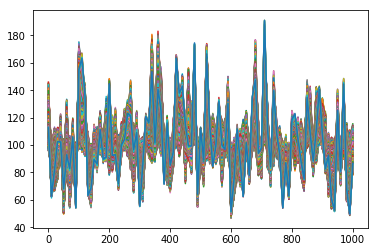

```python
plt.plot(x_to_gr,filtered_paths)
plt.show()
```

II. Payoffs

With our matrix of paths created, we can now calculate payoffs in each case, and finally the price of the product.

We have three things to look for:

- stock price outside of our barriers at time $a$
- stock price breaching the barriers between time $a$ to $b$
- stock price final value at time $T$

We can generate a payoff array by checking the various cases, and setting a payoff value accordingly.

```python
def payoff_calc(sp_matrix,check_dict):
    h_list = []
    # Garrison entry and exit times
    a,b = check_dict['a'], check_dict['b']
    # Full time to maturity
    Tm = len(sp_matrix[0])-1
    # High and Low price barriers
    H1,H2 = check_dict['H1'], check_dict['H2']

    def garrison_breach(some_path):
        """ find the payoff in the case the product was converted due to
        exceeding any barrier, at all, between times a and b."""

        g_payoff = 0

        H1_br_bool = any(some_path[a:b+1] > H1)
        H2_br_bool = any(some_path[a:b+1] < H2)

        # If there was an H1 or H2 breach, find the earliest index of this breach.
        # Otherwise this index is infinity.
        if H1_br_bool:
            h1bt = some_path[a:b+1] > H1
            H1_br_loc = min(np.where(h1bt)[0]) + a
        else:
            H1_br_loc = np.infty
        if H2_br_bool:
            h2bt = some_path[a:b+1] < H2
            H2_br_loc = min(np.where(h2bt)[0]) + a
        else:
            H2_br_loc = np.infty

        # We use only 1 underlying stock.
        # It's impossible to breach both barriers at the same time, unless H1=H2
        if H1_br_loc < H2_br_loc:
            # converted to call with strike S(a)
            g_payoff = max(path[H1_br_loc]-path[a],0)
        elif H2_br_loc < H1_br_loc:
            # converted to a put with strike S(a)
            g_payoff = max(path[a]- path[H2_br_loc],0)
        else:
            # This is an error. We return junk to force an error.
            g_payoff = "Issue in Garrison Function."
        return g_payoff

    for path in sp_matrix:
        # At time a, stock price must be between the barriers.
        if ((path[a] > H1) or (path[a] <H2)):
            h_list.append(0)
        # Between a and b, we can't exceed the barriers at all.
        # The 'any' function checks for this
        elif ( any(path[a:b+1] > H1) or any(path[a:b+1] < H2) ):
            g_payment = garrison_breach(path)
            h_list.append(g_payment)
        else:
            v_call = max(path[Tm]-path[b],0)
            v_put  = max(path[b]-path[Tm],0)
            v_payment = max(v_call,v_put)
            h_list.append(v_payment)
    return h_list
```

For simplicity we will take

- the end of the Waiting period, $a$, to be after $20\%$ of the option's life;
- the end of the Garrison area, $b$, to be after $80\%$ of the option's life;
- H1 and H2 to be $\pm \sigma \cdot T$ from our starting price $S_0$.

The last point makes sense, since (usually) $\sigma$ is anualized volatility, and $T$ is given in years. In $1$ year, we'd asusme the stock could rise or fall by $\sigma$. Therefore, this is a safe range or the barriers, that reduces the chance of breaching the Garrison to a repestable level.

```python
# Setup our barriers and critical times.
# We truncate into an integer, so that we can access the corresponding index.
a_calc = int(0.2*N)
b_calc = int(0.8*N)
h1_calc = s0*(1+vol)
h2_calc = max(s0*(1-vol),0) # since stock price can't be negative
limits = {
    'a': a_calc,
    'b': b_calc,
    'H1': h1_calc,
    'H2': h2_calc
}
limits
```

```
{'H1': 130.0, 'H2': 70.0, 'a': 200, 'b': 800}
```

```python
payoff_list = payoff_calc(all_path,limits)
```

```python
all_payoff = np.array(payoff_list)
```

##### Here are quick visualizations of our payoffs

- below is a sample from the 1000 payoffs

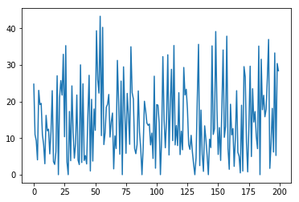

```python
# down-sampled distribution of payoffs
plt.plot(all_payoff[:1000:5])
plt.show()
```

- below this is a plot of all the payoffs

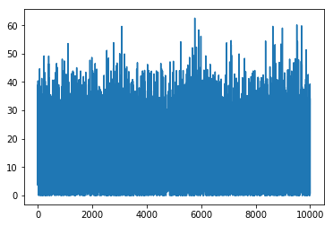

```python
# plot of all payoffs
plt.plot(all_payoff)
plt.show()
```

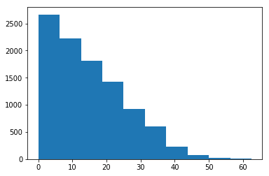

```python
payoff_hist = plt.hist(all_payoff)
```

- same graph as above, but with the densities

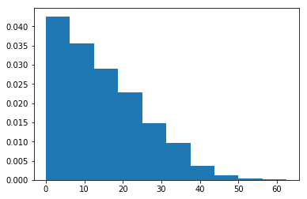

```python
wtd_payoff_hist = plt.hist(all_payoff,density=True)
plt.show()
```

- A horizontally displayed boxplot of our payoffs. In this orientation, it reminds us a bit of the time-based graph of the option mechanics.

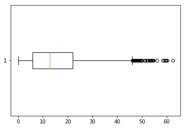

```python
boxpvar = plt.boxplot(all_payoff,vert=False)
plt.show()
```

- some diescriptive statistics about the distribution of payoffs

```python
boxpvar
```

[output not shown]

```python
po_disc = describe(all_payoff)
po_disc
```

```
DescribeResult(nobs=10001, minmax=(0.0, 62.533483989872565), mean=14.758028354556616, variance=119.33922938272183, skewness=0.7221028743817243, kurtosis=-0.011077367380878389)
```

* scroll down for a table with a summary of the payoffs

```python
# https://stackoverflow.com/questions/23349626/getting-data-of-a-box-plot-matplotlib
res = {key : [v.get_data() for v in value] for key, value in boxpvar.items()}
```

```python
# This obeject holds all of the information for plotting our boxplot.
# We can see that informaiton bewlow, and will use some of it in our summary table
res
```

```
{'boxes': [(array([  5.81593857,   5.81593857,  21.95419427,  21.95419427,   5.81593857]),
   array([ 0.925,  1.075,  1.075,  0.925,  0.925]))],
 'caps': [(array([ 0.,  0.]), array([ 0.9625,  1.0375])),
  (array([ 46.10674692,  46.10674692]), array([ 0.9625,  1.0375]))],
 'fliers': [(array([ 49.19504137,  49.15902564,  46.45488628,  46.55748667,
           48.08750291,  47.4475407 ,  53.57126556,  47.71208951,
           48.6939131 ,  46.53678246,  51.17210833,  48.4551507 ,
           53.89600207,  46.69287797,  50.03256551,  59.63087625,
           49.72344035,  49.90833853,  46.84987494,  46.20983105,
           46.57033607,  47.12353198,  47.3377844 ,  54.19973823,
           48.70753907,  52.10122947,  49.35621133,  62.53348399,
           52.2679286 ,  58.38404551,  56.14624876,  49.24610496,
           46.27028231,  53.83199844,  47.09837296,  54.62773189,
           53.1129626 ,  49.43800184,  49.08294622,  49.91181955,
           48.35978678,  54.4709807 ,  59.63995461,  51.18341554,
           53.1765128 ,  46.67013468,  46.93166252,  53.39000964,
           59.02975472,  48.06971197,  46.84836811,  48.25378561,
           60.15462464,  54.33207477,  47.86739652,  47.31100371,
           59.82589454,  46.28250894,  51.36141646]),
   array([ 1.,  1.,  1.,  1.,  1.,  1.,  1.,  1.,  1.,  1.,  1.,  1.,  1.,
           1.,  1.,  1.,  1.,  1.,  1.,  1.,  1.,  1.,  1.,  1.,  1.,  1.,
           1.,  1.,  1.,  1.,  1.,  1.,  1.,  1.,  1.,  1.,  1.,  1.,  1.,
           1.,  1.,  1.,  1.,  1.,  1.,  1.,  1.,  1.,  1.,  1.,  1.,  1.,
           1.,  1.,  1.,  1.,  1.,  1.,  1.]))],
 'means': [],
 'medians': [(array([ 12.82663841,  12.82663841]), array([ 0.925,  1.075]))],
 'whiskers': [(array([ 5.81593857,  0.        ]), array([ 1.,  1.])),
  (array([ 21.95419427,  46.10674692]), array([ 1.,  1.]))]}
```

*  
The `res` variable exposes all of the items within our boxplot above. If we compare this output with the boxplot, and add in what we have from the descrtiptive stats, we can summarize our payoffs for this particular simulaiton of the product like this:

| French Vanilla Option - Example Payoff Summary |  |  |  |  |  |  |  |  |
| --- | --- | --- | --- | --- | --- | --- | --- | --- |
| Mean | 14.758028 | Median | 12.826638 |  |  |  |  |  |
| $25th$ Percentile | 5.815938 | $75th$ Percentile | 21.954194 |  |  |  |  |  |
| $Q1-$1.5$\cdot$IQR | 0 | $Q3+$1.5$\cdot$IQR | 46.106746 |  |  |  |  |  |
| Minimum | 0 | Maximum | 62.533483 |  |  |  |  |  |
| Standard Dev. | $\approx \sqrt{119.3}=$ 10.9242 | Outliers | 59 ($< 1\%$) |  |  |  |  |  |

$ $

III. Pricing

We now get to pricing of the structured product.  
With our payoffs already determined, we will find a way to average them, and then discount back to our starting time.

- Average Payoff

```python
avg_payoff = describe(all_payoff).mean
avg_payoff
```

```
14.758028354556616
```

- Discounted Average Payoff

```python
disc_avg_payoff = avg_payoff * np.exp(-r*T)
disc_avg_payoff
```

```
14.03827081847011
```

IV. Scenario Analysis

Given the struture of the product, there are many scenarios, like edge-cases, we can take a look at. Some of these scenarios raise some questions about the structure of the product that haven't been discussed yet.

- What if $H_1 = H_2$? (Should this be allowed?)
- What if $b=a$ or $a=b$ ?  
  $\circ$ A shorter/longer waiting/chooser period  
  $\circ$ No Garrison. (Should this be allowed?)
- What are the best and worst case scenarios?

Best Case Scenarios

Product Buyer

1. Stock price rises steeply after being below $H_1$ until time $a$.  
   $\bullet$ best case strike price is $H_2$.  
   $\bullet$ payoff $max(S_T - H_2,0)$, where $H_2 = S_a$
2. Stock price drops steeply after being above $H_2$ until time $a$  
   $\bullet$ best case strike price is $H_1$.  
   $\bullet$ payoff $max(H_1 - S_T,0)$, where $H_1 = S_a$

   $\circ$ In the case of a put, the max payoff is $H_1$ since the stock can only go to zero.
3. Exact same stock price movement as Case-1 or Case-2, but product exits the Garrison  
   $\bullet$ to exit the Garrison, the price must between $H_1$ and $H_2$ at $t_b$  
   $\bullet$ The Vanilla chosen would maximize payoff.

   $\circ$ Best case scenario: *(same payoff as Case-1)* $S_b=K=H_2$ & stock price rises to $\infty$  
   $\circ$ Best case scenario: *(same payoff as Case-2)* $S_b=K=H_1$ & stock price drops to $0$
4. In our Example  
   $\bullet$ $S_0, K, r, q, vol, T$ = 100, 100, 0.05, 0, 0.3, 1  
   $\bullet$ $H_1 = S_0\cdot(1+vol)=130$  
   $\bullet$ $H_2 = S_0\cdot(1-vol)=70$

   $\circ$ Best payoff on Case-1 is unlimited: $max(S_T-70,0)$  
   $\circ$ Best payoff on Case-2 is 130: $max(H_1-S_T,0) = max(130-0,0) = 130$  
   $\circ$ Case-3 mirrors these.

In each case, the option holder would also have spent money to purchase the option. From above, this would be an additional expense of $14.04$ on average (for a product with a 1 year expiry).

If the structured product were sold, then the seller would face potential losses of $130-14.04=115.96$ in Case-2, and unlimited losses in Case-1. *These are in fact Seller "Worst" case scenarioa, but worth mentioning here since they are counterparts to the above.*

Product Seller

In this case, there's no payoff only profit. As such, we'd like the option to either cease to exist, or expire worthless.

1. Same as Buyer Worst Case-1 below. Profit of the premium.
2. Same as Buyer Worst Case-2 below. Profit of the premium.
3. Same as Buyer Worst Case-3 below. Profit of the premium.
4. Stock price drops to or stays below $S_a$ until time $T$, after first exceeding $H_1$  
   $\bullet$ This is one best case, for a seller, should the option enter the Garrison.  
   $\bullet$ The breach of $H_1$ between $t_a$ and $t_b$ converts the product to a call with strike $S_a$  
   $\bullet$ payoff (long position) is zero since $S_t$ is $\le$ $S_a$ at expiry  
   $\circ$ profit to the Seller is the option premium.
5. Stock price rises to or stays above $S_a$ until time $T$, after first breaching barrier $H_2$  
   $\bullet$ This is the a sellers other best case, should the option enter the Garrison.  
   $\bullet$ The breach of $H_2$ between $t_a$ and $t_b$ converts the product to a put with strike $S_a$  
   $\bullet$ payoff (long position) is zero since $S_t$ is $\ge$ $S_a$ at expiry  
   $\circ$ profit to the Seller is the option premium.

Worst Case Scenarios

Product Buyer

1. Stock price exceeds $H_1$ or is less than $H_2$ at time $a$  
   $\bullet$ payoff is zero, since the product ceases to exist
2. Stock price at time $t=T$ equals stock price at time $t=b$  
   $\bullet$ This is the worst case scenario if the product exits the Garrison.  
   $\bullet$ payoff is zero since $S_b$ is the strike price for the *chosen* Vanilla Call and Vanilla Put
3. Stock price at time $t=T$ equals stock price at time $t=a$  
   $\bullet$ This is the worst case scenario if the price ever breaks through either barrier after the waiting period.  
   $\bullet$ payoff is zero since $S_a$ is the strike price for the *converted* Call or Put

$\circ$ Buyer Summary: There are various ways to get a $0$ payoff. In terms of profit, there is a loss of the product premium. Thus the maximum loss for a buyer of the product is, just the price of the product - for example, $14.04$.

Product Seller

In addition to the complementary scenarios mentioned in Best Case, the seller of this product can lose in a few more ways. We'll list all of them.

1. Same as Buyer Best Case-1. Potential for unlimited losses.
2. Same as Buyer Best Case-2.  
   $\bullet$ worst case loss of $H_1 - option$ $premium$  
   $\bullet$ $130-14.04=115.96$ in our example
3. Same as Buyer Best Case-3  
   $\bullet$ Unlimited loss should stock price go to $\infty$  
   $\circ$ holder would select Vanilla Call, and exercise at at strike as low as $K=S_b=H_2$  
   $\circ$ As the seller, we'd have to buy on the market to deliver the stock  
   $\bullet$ Maximum loss of $S_b - S_T$ should stock price go to $0$  
   $\circ$ holder would select Vanilla Put, and exercise at at strike as high as $K=S_b=H_1$  
   $\circ$ As the seller, we'd have to buy a (near) worthless stock from the exercisee of the put

$\circ$ Seller Summary: Overall, the Seller has less advantageous positions using this product. This is because, in various cases, the product converts in a way that is more useful to the buyer. *Note that in the Seller Worst Case-3, if the price actually was zero, the buyer could likely **not** "buy" a $0$-valued stock to sell to the seller, but we understand the premise.*

V. Sensitivity Analysis

Aside - Computational Problems:  
The array object in the NumPy package was not designed for operations like "appending". Rather, it was designed/optimized for math operations. Unlike lists and other similar objects in Python, the NumPy array functions `concatenate, hstack, vstack` create a copy of the object being worked with. In our simulation above, this meant that while we tried to avoid the issues of having a double loop, it was still wildly inefficient using memory.  
For Sensitivity Analysis, we'll rebuild the _simulator_ using just lists. Then we will convert the final output to a NumPy array, so that we can still use the payoff function above. This should speed up the creation/storing of multiple paths significantly.

Checking that our new method isn't drastically different from the previous. Here's 3 sets of 10K sims of 1K steps have their discounted prices calculated and compared to the first set. The small difference implies, that there were no major slip-ups in re-writing the simulation code set: [price, difference]  
{1: [14.608992706429675, 0.040526546041999671],  
2: [14.479951810639502, 0.031335599048397639],  
3: [14.218511640913736, 0.012714504338585229]}

However, we are unable to get back down to a number like $14.04$. Why?

When I rebuilt the stock path simulator, and repriced the product, the value was 2% higher than in the sections on Payoffs and Pricing. Thus, I ran the 10K simulations a few more times to get a new discounted price. Each time, there was some discrepancy.

It was a bit annoying feeling like I didn't have a sound grasp on the discounted product price. While the ~2% difference sounds small, after some other tests, it could vary from negative (i.e. less than 14.04) to, say, 4% greater. To mitigate this, simulation code was rewritten outside of the Jupyter notebook, in a base Python *.py* file, and run from the terminal to reduce memory usage.

| Discounted Price | Steps per path : N | Path Simulations : M |
| --- | --- | --- |
| 14.34041515 | 5000 | 25000 |
| 14.25492236 | 4000 | 30000 |
| 14.34971083 | 3000 | 40000 |
| 14.39870052 | 2000 | 60000 |
| 14.31935133 | 1000 | 120000 |

| **Averages** | **Type** |  |
| --- | --- | --- |
| 14.33262004 | equal-weighted average |  |
| 14.32584334 | N-weighted average |  |
| 14.33596609 | M-weighted average |  |
| 14.33268446 | NM-weighted average |  |
|  | $Average$ $of$ $Averages$ | $14.33177848$ |

A. Sensitivity Parameters

We will check the sensitivity of the Product Price to

Increases Stock Price,

Increases in the Risk-free rate,

Increases in Volatility,

Decreases in the Garrison price-width,

Decreases in the Garrison time-window.

This should give us a sense of which paramter has the greatest effect on price per unit change.

```python
# to run a massive sim of a sturctured product and find its value
# original version run via terminal
# modified to work well within Jupyter Notebook

import numpy as np
# define the variables
_iv = {'s0':100,'K':100,'r':0.05,'q':0,'vol':0.3,'T':1}
_load= dict(N=30,M=60)

# define barriers and cut-off points
def limits(iva,ldb):
    a_calc = int(0.2*ldb['N'])
    b_calc = int(0.8*ldb['N'])
    h1_calc = iva['s0']*(1+iva['vol'])
    h2_calc = max(iva['s0']*(1-iva['vol']),0) # since stock price can't be negative
    lim = {'a': a_calc,'b': b_calc,'H1': h1_calc,'H2': h2_calc}
    return lim

# where to write data
# we can add a newline for each sensitivity test
discountfile = 'sense_tests'

# where to put each path
list_of_paths = []

# define geo brownian mtn
def g_stock_path(s0,K,r,q,vol,T,N,M):
    """Generates N values of stock price from time 0 to T.
    Stock price follow geometric brownian motion.
    Uses lists, instead of numpy arrays"""
    dt=T/N
    s = [s0]
    temp1 = ((r - q) - (0.5 * vol*vol))*dt
    temp2 = vol * np.sqrt(dt)
    for step in range(N):
        next_val = s[step] * np.exp(temp1 + (temp2 * np.random.randn()))
        s.append(next_val)
    return s

# generate multiple paths and put them above
def g_sims(s0,K,r,q,vol,T,N,M):
    for sims in range(M):
        new_path = g_stock_path(s0,K,r,q,vol,T,N,M)
        list_of_paths.append(new_path)
        if ((sims+1)%5000==0):
            print(sims+1)

# define the payoffs
def payoff_calc(sp_matrix,check_dict):
    h_list = []
    # Garrison entry and exit times
    a,b = check_dict['a'], check_dict['b']
    # Full time to maturity
    Tm = len(sp_matrix[0])-1
    # High and Low price barriers
    H1,H2 = check_dict['H1'], check_dict['H2']

    def garrison_breach(some_path):
        """ find the payoff in the case the product was converted due to
        exceeding any barrier, at all, between times a and b."""

        some_path = np.array(some_path)

        g_payoff = 0

        H1_br_bool = any(some_path[a:b+1] > H1)
        H2_br_bool = any(some_path[a:b+1] < H2)

        # If there was an H1 or H2 breach, find the earliest index of this breach.
        # Otherwise this index is infinity.
        if H1_br_bool:
            h1bt = some_path[a:b+1] > H1
            H1_br_loc = min(np.where(h1bt)[0]) + a
        else:
            H1_br_loc = np.infty
        if H2_br_bool:
            h2bt = some_path[a:b+1] < H2
            H2_br_loc = min(np.where(h2bt)[0]) + a
        else:
            H2_br_loc = np.infty

        # We use only 1 underlying stock.
        # It's impossible to breach both barriers at the same time, unless H1=H2
        if H1_br_loc < H2_br_loc:
            # converted to call with strike S(a)
            #g_payoff = max(path[H1_br_loc]-path[a],0)
            g_payoff = max(path[H1_br_loc]-path[a],0)
        elif H2_br_loc < H1_br_loc:
            # converted to a put with strike S(a)
            g_payoff = max(path[a]- path[H2_br_loc],0)
        else:
            # This is an error. We return junk to force an error.
            g_payoff = "Issue in Garrison Function."
        return g_payoff

    for path in sp_matrix:
        path = np.array(path)
        # At time a, stock price must be between the barriers.
        if ((path[a] > H1) or (path[a] <H2)):
            h_list.append(0)
        # Between a and b, we can't exceed the barriers at all.
        # The 'any' function checks for this
        elif ( any(path[a:b+1] > H1) or any(path[a:b+1] < H2) ):
            g_payment = garrison_breach(path)
            h_list.append(g_payment)
        else:
            v_call = max(path[Tm]-path[b],0)
            v_put  = max(path[b]-path[Tm],0)
            v_payment = max(v_call,v_put)
            h_list.append(v_payment)
    return h_list

# the_payoffs = payoff_calc(list_of_paths,limits)
def discounted_payoffs(pyf):
    r,T = _iv['r'],_iv['T']
    return np.average(pyf) * np.exp(-r*T)

def store_trial(s0,K,r,q,vol,T,N,M,lim_replace=''):
    global list_of_paths
    list_of_paths = []


    # reassign default vars with what's passed in
    _iv['s0'],_iv['K'],_iv['r'],_iv['q'],_iv['vol'],_iv['T'] = s0,K,r,q,vol,T
    _load['N'],_load['M'] = N,M



    g_sims(_iv['s0'],_iv['K'],_iv['r'],_iv['q'],_iv['vol'],_iv['T'],_load['N'],_load['M'])
    if not lim_replace:
        limz = limits(_iv,_load)
    else:
        limz = lim_replace

    payoffs = payoff_calc(list_of_paths,limz)
    dsc_payoffs = discounted_payoffs(payoffs)

    out_put = open(discountfile,'a')
    myline = str(dsc_payoffs) + ',' + str(_load['N']) + ',' + str(_load['M'])

    abh1h2 = [str(v) for v in list(limz.values())]
    abh1h2_joined = ','.join(abh1h2)

    myline +=','
    myline += abh1h2_joined

    baseparams ="{},{},{},{},{},{}".format(_iv['s0'],_iv['K'],_iv['r'],
                                           _iv['q'],_iv['vol'],_iv['T'])

    myline +=','
    myline += baseparams
    out_put.write(myline)
    out_put.write('\n')
    out_put.close()

print(limits(_iv,_load))
```

```
{'a': 6, 'b': 24, 'H1': 130.0, 'H2': 70.0}
```

B. Sensitivity Test Suite

a. Base Case

```python
store_trial(100,100,0.05,0,0.3,1,2000,40000)
```

b. Starting Stock price change

```python
# 2% increase
store_trial(102,100,0.05,0,0.3,1,2000,40000)
# 4% increase
store_trial(104,100,0.05,0,0.3,1,2000,40000)
# 8% increase
store_trial(108,100,0.05,0,0.3,1,2000,40000)
```

c. Risk-free rate change

```python
# 2% increase
old_r=0.05
store_trial(100,100,old_r*1.02,0,0.3,1,2000,40000)
# 4% increase
store_trial(100,100,old_r*1.04,0,0.3,1,2000,40000)
# 8% increase
store_trial(100,100,old_r*1.08,0,0.3,1,2000,40000)
# 20% increase
store_trial(100,100,old_r*1.2,0,0.3,1,2000,40000)
```

d. Dividend Yield Change

```python
comp_r = 0.02
# comparison case
store_trial(100,100,0.05,comp_r,0.3,1,2000,40000)
# 2% increase
store_trial(100,100,0.05,comp_r*1.02,0.3,1,2000,40000)
# 4% increase
store_trial(100,100,0.05,comp_r*1.04,0.3,1,2000,40000)
# 8% increase
store_trial(100,100,0.05,comp_r*1.08,0.3,1,2000,40000)
```

e. Volatility Change

```python
old_vol = 0.3
# 2% increase
store_trial(100,100,0.05,0,old_vol*1.02,1,2000,40000)
# 4% increase
store_trial(100,100,0.05,0,old_vol*1.04,1,2000,40000)
# 8% increase
store_trial(100,100,0.05,0,old_vol*1.08,1,2000,40000)
# 20% increase
store_trial(100,100,0.05,0,old_vol*1.2,1,2000,40000)
```

f. Time to Maturity Change

```python
old_T =1
# 25% increase
store_trial(100,100,0.05,0,0.3,old_T*1.25,2000,40000)
# 50% increase
store_trial(100,100,0.05,0,0.3,old_T*1.5,2000,40000)
# 100% increase
store_trial(100,100,0.05,0,0.3,old_T*2,2000,40000)
# 50% decrease
store_trial(100,100,0.05,0,0.3,old_T*0.5,2000,40000)
```

h. Barrier-width change

```python
def_limits = {'a':400,'b':1600,'H1':130,'H2':70}
d2d = {'a':def_limits['a'],'b':def_limits['b'],'H1':120,'H2':80}
d1d = {'a':def_limits['a'],'b':def_limits['b'],'H1':110,'H2':90}
d4i = {'a':def_limits['a'],'b':def_limits['b'],'H1':140,'H2':60}
d6i = {'a':def_limits['a'],'b':def_limits['b'],'H1':160,'H2':40}

d5i = {'a':def_limits['a'],'b':def_limits['b'],'H1':150,'H2':50}
d0inc = {'a':def_limits['a'],'b':def_limits['b'],'H1':200,'H2':0}

# 20% range
store_trial(100,100,0.05,0,0.3,1,2000,40000,lim_replace=d2d)
# 10% range
store_trial(100,100,0.05,0,0.3,1,2000,40000,lim_replace=d1d)
# 40% range
store_trial(100,100,0.05,0,0.3,1,2000,40000,lim_replace=d4i)
# 60% range
store_trial(100,100,0.05,0,0.3,1,2000,40000,lim_replace=d6i)

# 50% range
store_trial(100,100,0.05,0,0.3,1,2000,40000,lim_replace=d5i)
# 100% range
store_trial(100,100,0.05,0,0.3,1,2000,40000,lim_replace=d0inc)
```

i. Garrison period change

```python
def_limits = {'a':400,'b':1600,'H1':130,'H2':70}
L1090 = {'a':200,'b':1800,'H1':130,'H2':70}
L3070 = {'a':600,'b':1400,'H1':130,'H2':70}
L4060 = {'a':800,'b':1200,'H1':130,'H2':70}
L0199 = {'a':20,'b':1980,'H1':130,'H2':70}
L4951 = {'a':980,'b':1020,'H1':130,'H2':70}
# [10,90]
store_trial(100,100,0.05,0,0.3,1,2000,40000,lim_replace=L1090)
# [30,70]
store_trial(100,100,0.05,0,0.3,1,2000,40000,lim_replace=L3070)
# [40,60]
store_trial(100,100,0.05,0,0.3,1,2000,40000,lim_replace=L4060)
# [1,99]
store_trial(100,100,0.05,0,0.3,1,2000,40000,lim_replace=L0199)
# [49,50]
store_trial(100,100,0.05,0,0.3,1,2000,40000,lim_replace=L4951)
```

j. Garrison Period Special Case

$t_a=t_b$

- Centered in the product duration
- At the default position for $a$
- At the default position for $b$

```python
L5050a = {'a':400,'b':400,'H1':130,'H2':70}
L5050b = {'a':1600,'b':1600,'H1':130,'H2':70}
L5050c = {'a':1000,'b':1000,'H1':130,'H2':70}

# [a,a] --> 20% of Time to maturity
store_trial(100,100,0.05,0,0.3,1,2000,40000,lim_replace=L5050a)
# [b,b] --> 80% of Time to maturity
store_trial(100,100,0.05,0,0.3,1,2000,40000,lim_replace=L5050b)
# [c,c] --> 50% of Time to maturity
store_trial(100,100,0.05,0,0.3,1,2000,40000,lim_replace=L5050c)
```

k. Garrison Width Special Case

$H_1 = H_2$

This is a *near* impossible case. At time $t_a$, if $H_1=H_2$ then

- $S_a$ will either be above both, below both or equal to both
  - If $S_a$ is **not** equal to both, then at time $t_a$ it cannot be both below $H_1$, and above $H_2$.
  - Therefore the product ceases to exist.

```python
knock_up = {'a':400,'b':1600,'H1':130,'H2':130}
knock_down = {'a':400,'b':1600,'H1':70,'H2':70}
knock_knock = {'a':400,'b':1600,'H1':100,'H2':100}

# H1=H2 and they start above S0
store_trial(100,100,0.05,0,0.3,1,2000,40000,lim_replace=knock_up)
# H1=H2 and they start below S0
store_trial(100,100,0.05,0,0.3,1,2000,40000,lim_replace=knock_down)
# H1=H2 = S0
store_trial(100,100,0.05,0,0.3,1,2000,40000,lim_replace=knock_knock)
```

A full treatment of the results from testing the product sensitivity can be found in the main report.